# Biostat 203B Homework 4

Author

Yufan Gong (UID: 305301666)

Published

March 22, 2023

Load database libraries and the tidyverse frontend:

```r
suppressPackageStartupMessages(library(tidymodels))
suppressPackageStartupMessages(library(here))
suppressPackageStartupMessages(library(rlang))
suppressPackageStartupMessages(library(ranger))
suppressPackageStartupMessages(library(xgboost))
suppressPackageStartupMessages(library(gtsummary))
suppressPackageStartupMessages(library(tidyverse))
```

## 1 Predicting 30-day mortality

Using the ICU cohort `icu_cohort.rds` you built in Homework 3, develop at least three analytic approaches for predicting the 30-day mortality of patients admitted to ICU using demographic information (gender, age, marital status, ethnicity), first lab measurements during ICU stay, and first vital measurements during ICU stay. For example, you can use (1) logistic regression with elastic net (lasso + ridge) penalty (e.g., glmnet or keras package), (2) random forest, (3) boosting, and (4) support vector machines, or (5) MLP neural network (keras package)

1. Partition data into 50% training set and 50% test set. Stratify partitioning according the 30-day mortality status.

First, we need to copy `icu_cohort.rds` from `hw3` to `hw4`.

```r
# Copy icu_cohort.rds from hw3 to hw4

# Set the source and destination directories
hw3_path <- here("hw3", "mimiciv_shiny")
hw4_path <- here("hw4")

# Set the file name and path
file_name <- "icu_cohort.rds"
file_path <- file.path(hw3_path, file_name)

# check if the file already exists in the destination directory
if (!file.exists(str_c(hw4_path, "/", file_name))) {
  # copy the file to the destination directory
  file.copy(from = file_path,
            to = hw4_path)
  print("File copied successfully!")
} else {
  print("File already exists in the destination directory.")
}
```

```
[1] "File copied successfully!"
```

Then, we need to make a subset of the original dataset with variables of interest and remove the outliers.

```r
#create functions

## quote all elements in a list
quote_all <- function(...){
  args <- ensyms(...)
  paste(map(args, as_string), sep = "")
}

## remove extreme values based on their iqrs
extreme_remove_iqr <- function(x) {
  Q = quantile(x, c(0.25, 0.75), na.rm = TRUE)
  iqr = IQR(x, na.rm = TRUE)
  x = if_else(x < Q[1] - 1.5 * iqr | x > Q[2] + 1.5 * iqr, NA, x)
}


#Load data
icu_cohort <- read_rds("icu_cohort.rds")

#only keep variables that could contribute to thirty day mortality
vars_to_drop <- quote_all(time, `_id`, dod, los, location, flag, year,
                          unit, language, anchor, length, type, insurance)

covars <- names(icu_cohort) %>%
  discard(
         str_detect(
           .,
           str_c(vars_to_drop, collapse = "|")
           )
       )

#get the subset which only contains variables of interest
icu_cohort_new <- icu_cohort %>%
  select(all_of(covars)) %>%
  mutate_if(is.numeric, extreme_remove_iqr) # remove outliers

icu_cohort_new %>%
  tbl_summary(by = thirty_day_mort, missing = "no") %>%
  add_n() %>%
      add_overall() %>%
      modify_header(label = "**Characteristics**") %>%
      modify_spanning_header(
        starts_with("stat_") ~ "**Thirty day mortality**"
      ) %>%
  modify_caption("Table 1. Characteristics of MIMIC IV") %>%
  bold_labels() %>%
  as_flex_table()
```

| Characteristics | N | Thirty day mortality Overall, N = 53,1501 | Thirty day mortality Didn't Die Within 30 Days, N = 47,9371 | Thirty day mortality Died Within 30 Days, N = 5,2131 |
| --- | --- | --- | --- | --- |
| marital_status | 48,519 |  |  |  |
| Divorced |  | 3,695 (7.6%) | 3,399 (7.7%) | 296 (7.1%) |
| Married |  | 24,112 (50%) | 22,062 (50%) | 2,050 (49%) |
| Single |  | 14,242 (29%) | 13,241 (30%) | 1,001 (24%) |
| Widowed |  | 6,470 (13%) | 5,629 (13%) | 841 (20%) |
| ethnicity | 53,150 |  |  |  |
| American Indian/Alaska Native |  | 94 (0.2%) | 87 (0.2%) | 7 (0.1%) |
| Asian |  | 1,564 (2.9%) | 1,403 (2.9%) | 161 (3.1%) |
| Black/African American |  | 4,874 (9.2%) | 4,494 (9.4%) | 380 (7.3%) |
| Hispanic/Latino |  | 1,827 (3.4%) | 1,712 (3.6%) | 115 (2.2%) |
| Other |  | 2,537 (4.8%) | 2,326 (4.9%) | 211 (4.0%) |
| Unable To Obtain |  | 759 (1.4%) | 639 (1.3%) | 120 (2.3%) |
| Unknown |  | 5,827 (11%) | 4,691 (9.8%) | 1,136 (22%) |
| White |  | 35,668 (67%) | 32,585 (68%) | 3,083 (59%) |
| gender | 53,150 |  |  |  |
| F |  | 23,353 (44%) | 20,940 (44%) | 2,413 (46%) |
| M |  | 29,797 (56%) | 26,997 (56%) | 2,800 (54%) |
| age_at_admission | 53,150 | 66 (54, 78) | 66 (53, 77) | 74 (61, 84) |
| bicarbonate | 48,176 | 23.0 (21.0, 25.0) | 23.0 (21.0, 25.0) | 22.0 (19.0, 25.0) |
| white_blood_cells | 48,982 | 10.3 (7.5, 13.9) | 10.2 (7.5, 13.7) | 11.8 (8.1, 16.0) |
| glucose | 47,686 | 121 (102, 147) | 120 (102, 146) | 130 (103, 162) |
| hematocrit | 50,873 | 33 (28, 37) | 33 (28, 37) | 32 (27, 37) |
| creatinine | 46,400 | 0.90 (0.70, 1.10) | 0.90 (0.70, 1.10) | 1.10 (0.80, 1.50) |
| sodium | 49,030 | 139.0 (136.0, 141.0) | 139.0 (137.0, 141.0) | 139.0 (135.0, 142.0) |
| chloride | 49,578 | 105.0 (101.0, 108.0) | 105.0 (102.0, 108.0) | 104.0 (99.0, 108.0) |
| potassium | 49,466 | 4.10 (3.70, 4.50) | 4.10 (3.70, 4.40) | 4.20 (3.70, 4.60) |
| temperature_fahrenheit | 48,263 | 98.10 (97.70, 98.60) | 98.10 (97.70, 98.60) | 98.00 (97.50, 98.60) |
| non_invasive_blood_pressure_systolic | 51,888 | 122 (106, 139) | 122 (107, 139) | 117 (100, 137) |
| heart_rate | 52,159 | 85 (74, 98) | 84 (73, 97) | 91 (77, 106) |
| respiratory_rate | 51,463 | 18.0 (15.0, 21.0) | 17.0 (14.0, 21.0) | 20.0 (16.0, 24.0) |
| non_invasive_blood_pressure_mean | 51,464 | 80 (70, 92) | 81 (70, 93) | 78 (66, 91) |

1n (%); Median (IQR)

After data cleaning, we can split the data into `training` set and `testing` set for analysis.

```r
#Split data into test and training set
data_split <- initial_split(
  icu_cohort_new,
  # stratify by 30-day mortality status
  strata = "thirty_day_mort",
  prop = 0.5
  )

data_split
```

```
<Training/Testing/Total>
<26575/26575/53150>
```

```r
list(training, testing) %>%
  map(~ data_split %>%
        .x) %>%
  set_names("icu_cohort_training", "icu_cohort_testing") %>%
  list2env(.GlobalEnv) %>%
  invisible()

dim(icu_cohort_training)
```

```
[1] 26575    18
```

```r
dim(icu_cohort_testing)
```

```
[1] 26575    18
```

2. Train and tune the models using the training set.

I used logistic regression, random forest, and boosting to train the models. I intended to impute the predictors since I removed some outliers. The existence of extreme values could just be due to entry error which is common in such a big database.

```r
rf_recipe <-
  recipe(
    thirty_day_mort ~ .,
    data = icu_cohort_training
  ) %>%
  # mean imputation for numeric_var
  step_impute_mean(all_numeric_predictors()) %>%
  # mode imputation for categorical_var
  step_impute_mode(all_nominal_predictors()) %>%
  # # create traditional dummy variables (not necessary for random forest in R)
  # step_dummy(all_nominal_predictors()) %>%
  # zero-variance filter
  step_zv(all_numeric_predictors())
  # # center and scale numeric data (not necessary for random forest)
  # step_normalize(all_numeric_predictors()) %>%
rf_recipe

logit_recipe <-
  rf_recipe %>%
  step_dummy(all_nominal_predictors()) %>%
  # # center and scale numeric data (not necessary for random forest)
  step_normalize(all_numeric_predictors())
logit_recipe

gb_recipe <-
  rf_recipe %>%
  # create traditional dummy variables (necessary for xgboost)
  step_dummy(all_nominal_predictors())
gb_recipe
```

```r
# Models
logit_mod <-
  logistic_reg(
    penalty = tune(),
    mixture = tune()
  ) %>%
  set_engine("glmnet", standardize = FALSE)
logit_mod
```

```
Logistic Regression Model Specification (classification)

Main Arguments:
  penalty = tune()
  mixture = tune()

Engine-Specific Arguments:
  standardize = FALSE

Computational engine: glmnet
```

```r
rf_mod <-
  rand_forest(
    mode = "classification",
    # Number of predictors randomly sampled in each split
    mtry = tune(),
    # Number of trees in ensemble
    trees = tune()
  ) %>%
  set_engine("ranger")
rf_mod
```

```
Random Forest Model Specification (classification)

Main Arguments:
  mtry = tune()
  trees = tune()

Computational engine: ranger
```

```r
gb_mod <-
  boost_tree(
    mode = "classification",
    trees = 1000,
    tree_depth = tune(),
    learn_rate = tune()
  ) %>%
  set_engine("xgboost")
gb_mod
```

```
Boosted Tree Model Specification (classification)

Main Arguments:
  trees = 1000
  tree_depth = tune()
  learn_rate = tune()

Computational engine: xgboost
```

```r
# Workflows
list(
  list(logit_recipe, rf_recipe, gb_recipe),
  list(logit_mod, rf_mod, gb_mod)
  ) %>%
  pmap(
    ~ workflow() %>%
      add_recipe(.x) %>%
      add_model(.y)
  ) %>%
  set_names("logit_wf", "rf_wf", "gb_wf") %>%
  list2env(.GlobalEnv) %>%
  invisible()

logit_wf
```

```
══ Workflow ════════════════════════════════════════════════════════════════════
Preprocessor: Recipe
Model: logistic_reg()

── Preprocessor ────────────────────────────────────────────────────────────────
5 Recipe Steps

• step_impute_mean()
• step_impute_mode()
• step_zv()
• step_dummy()
• step_normalize()

── Model ───────────────────────────────────────────────────────────────────────
Logistic Regression Model Specification (classification)

Main Arguments:
  penalty = tune()
  mixture = tune()

Engine-Specific Arguments:
  standardize = FALSE

Computational engine: glmnet
```

```r
rf_wf
```

```
══ Workflow ════════════════════════════════════════════════════════════════════
Preprocessor: Recipe
Model: rand_forest()

── Preprocessor ────────────────────────────────────────────────────────────────
3 Recipe Steps

• step_impute_mean()
• step_impute_mode()
• step_zv()

── Model ───────────────────────────────────────────────────────────────────────
Random Forest Model Specification (classification)

Main Arguments:
  mtry = tune()
  trees = tune()

Computational engine: ranger
```

```r
gb_wf
```

```
══ Workflow ════════════════════════════════════════════════════════════════════
Preprocessor: Recipe
Model: boost_tree()

── Preprocessor ────────────────────────────────────────────────────────────────
4 Recipe Steps

• step_impute_mean()
• step_impute_mode()
• step_zv()
• step_dummy()

── Model ───────────────────────────────────────────────────────────────────────
Boosted Tree Model Specification (classification)

Main Arguments:
  trees = 1000
  tree_depth = tune()
  learn_rate = tune()

Computational engine: xgboost
```

```r
# Tuning grid
param_grid_logit <- grid_regular(
  penalty(range = c(-6, 3)),
  mixture(),
  levels = c(100, 5)
  )
param_grid_logit
```

```
# A tibble: 500 × 2
      penalty mixture
        <dbl>   <dbl>
 1 0.000001         0
 2 0.00000123       0
 3 0.00000152       0
 4 0.00000187       0
 5 0.00000231       0
 6 0.00000285       0
 7 0.00000351       0
 8 0.00000433       0
 9 0.00000534       0
10 0.00000658       0
# … with 490 more rows
```

```r
param_grid_rf <- grid_regular(
  trees(range = c(100L, 300L)),
  mtry(range = c(1L, 5L)),
  levels = c(3, 5)
  )
param_grid_rf
```

```
# A tibble: 15 × 2
   trees  mtry
   <int> <int>
 1   100     1
 2   200     1
 3   300     1
 4   100     2
 5   200     2
 6   300     2
 7   100     3
 8   200     3
 9   300     3
10   100     4
11   200     4
12   300     4
13   100     5
14   200     5
15   300     5
```

```r
param_grid_boost <- grid_regular(
  tree_depth(range = c(1L, 3L)),
  learn_rate(range = c(-5, 2), trans = log10_trans()),
  levels = c(3, 10)
  )
param_grid_boost
```

```
# A tibble: 30 × 2
   tree_depth learn_rate
        <int>      <dbl>
 1          1  0.00001
 2          2  0.00001
 3          3  0.00001
 4          1  0.0000599
 5          2  0.0000599
 6          3  0.0000599
 7          1  0.000359
 8          2  0.000359
 9          3  0.000359
10          1  0.00215
# … with 20 more rows
```

```r
set.seed(203)

folds <- vfold_cv(icu_cohort_training, v = 5)
folds
```

```
#  5-fold cross-validation
# A tibble: 5 × 2
  splits               id
  <list>               <chr>
1 <split [21260/5315]> Fold1
2 <split [21260/5315]> Fold2
3 <split [21260/5315]> Fold3
4 <split [21260/5315]> Fold4
5 <split [21260/5315]> Fold5
```

```r
list(
  list(logit_wf, rf_wf, gb_wf),
  list(param_grid_logit, param_grid_rf, param_grid_boost)
  ) %>%
  pmap(
    ~ .x %>%
      tune_grid(
        resamples = folds,
        grid = .y,
        metrics = metric_set(roc_auc, accuracy)
        )
    ) %>%
  set_names("logit_fit", "rf_fit", "gb_fit") %>%
  list2env(.GlobalEnv) %>%
  invisible()

logit_fit
```

```
# Tuning results
# 5-fold cross-validation
# A tibble: 5 × 4
  splits               id    .metrics             .notes
  <list>               <chr> <list>               <list>
1 <split [21260/5315]> Fold1 <tibble [1,000 × 6]> <tibble [0 × 3]>
2 <split [21260/5315]> Fold2 <tibble [1,000 × 6]> <tibble [0 × 3]>
3 <split [21260/5315]> Fold3 <tibble [1,000 × 6]> <tibble [0 × 3]>
4 <split [21260/5315]> Fold4 <tibble [1,000 × 6]> <tibble [0 × 3]>
5 <split [21260/5315]> Fold5 <tibble [1,000 × 6]> <tibble [0 × 3]>
```

```r
rf_fit
```

```
# Tuning results
# 5-fold cross-validation
# A tibble: 5 × 4
  splits               id    .metrics          .notes
  <list>               <chr> <list>            <list>
1 <split [21260/5315]> Fold1 <tibble [30 × 6]> <tibble [0 × 3]>
2 <split [21260/5315]> Fold2 <tibble [30 × 6]> <tibble [0 × 3]>
3 <split [21260/5315]> Fold3 <tibble [30 × 6]> <tibble [0 × 3]>
4 <split [21260/5315]> Fold4 <tibble [30 × 6]> <tibble [0 × 3]>
5 <split [21260/5315]> Fold5 <tibble [30 × 6]> <tibble [0 × 3]>
```

```r
gb_fit
```

```
# Tuning results
# 5-fold cross-validation
# A tibble: 5 × 4
  splits               id    .metrics          .notes
  <list>               <chr> <list>            <list>
1 <split [21260/5315]> Fold1 <tibble [60 × 6]> <tibble [0 × 3]>
2 <split [21260/5315]> Fold2 <tibble [60 × 6]> <tibble [0 × 3]>
3 <split [21260/5315]> Fold3 <tibble [60 × 6]> <tibble [0 × 3]>
4 <split [21260/5315]> Fold4 <tibble [60 × 6]> <tibble [0 × 3]>
5 <split [21260/5315]> Fold5 <tibble [60 × 6]> <tibble [0 × 3]>
```

```
# A tibble: 1,000 × 8
      penalty mixture .metric  .estimator  mean     n std_err
        <dbl>   <dbl> <chr>    <chr>      <dbl> <int>   <dbl>
 1 0.000001         0 accuracy binary     0.903     5 0.00105
 2 0.000001         0 roc_auc  binary     0.754     5 0.00243
 3 0.00000123       0 accuracy binary     0.903     5 0.00105
 4 0.00000123       0 roc_auc  binary     0.754     5 0.00243
 5 0.00000152       0 accuracy binary     0.903     5 0.00105
 6 0.00000152       0 roc_auc  binary     0.754     5 0.00243
 7 0.00000187       0 accuracy binary     0.903     5 0.00105
 8 0.00000187       0 roc_auc  binary     0.754     5 0.00243
 9 0.00000231       0 accuracy binary     0.903     5 0.00105
10 0.00000231       0 roc_auc  binary     0.754     5 0.00243
   .config
   <chr>
 1 Preprocessor1_Model001
 2 Preprocessor1_Model001
 3 Preprocessor1_Model002
 4 Preprocessor1_Model002
 5 Preprocessor1_Model003
 6 Preprocessor1_Model003
 7 Preprocessor1_Model004
 8 Preprocessor1_Model004
 9 Preprocessor1_Model005
10 Preprocessor1_Model005
# … with 990 more rows
```

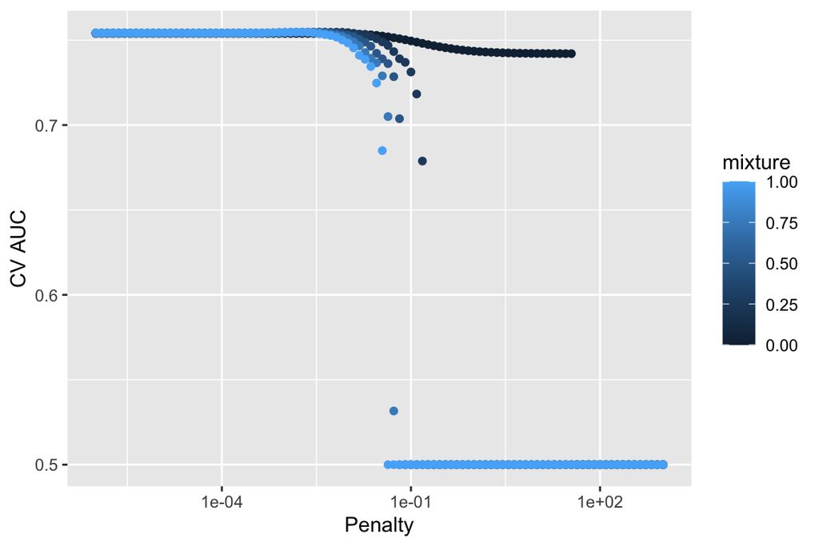

```r
logit_fit %>%
  collect_metrics() %>%
  print(width = Inf) %>%
  filter(.metric == "roc_auc") %>%
  ggplot(mapping = aes(x = penalty, y = mean, color = mixture)) +
  geom_point() +
  labs(x = "Penalty", y = "CV AUC") +
  scale_x_log10()
```

```
# A tibble: 30 × 8
    mtry trees .metric  .estimator  mean     n  std_err .config
   <int> <int> <chr>    <chr>      <dbl> <int>    <dbl> <chr>
 1     1   100 accuracy binary     0.903     5 0.000736 Preprocessor1_Model01
 2     1   100 roc_auc  binary     0.801     5 0.00427  Preprocessor1_Model01
 3     1   200 accuracy binary     0.902     5 0.000745 Preprocessor1_Model02
 4     1   200 roc_auc  binary     0.810     5 0.00235  Preprocessor1_Model02
 5     1   300 accuracy binary     0.903     5 0.000717 Preprocessor1_Model03
 6     1   300 roc_auc  binary     0.809     5 0.00278  Preprocessor1_Model03
 7     2   100 accuracy binary     0.904     5 0.000408 Preprocessor1_Model04
 8     2   100 roc_auc  binary     0.804     5 0.00253  Preprocessor1_Model04
 9     2   200 accuracy binary     0.904     5 0.000478 Preprocessor1_Model05
10     2   200 roc_auc  binary     0.809     5 0.00319  Preprocessor1_Model05
# … with 20 more rows
```

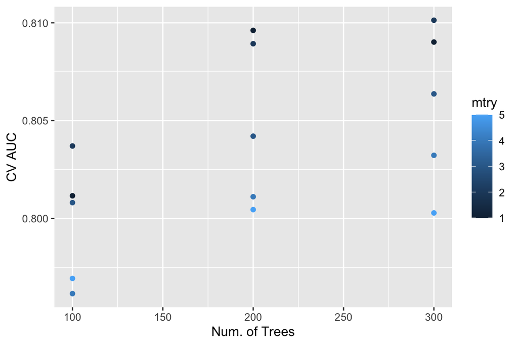

```r
rf_fit %>%
  collect_metrics() %>%
  print(width = Inf) %>%
  filter(.metric == "roc_auc") %>%
  ggplot(mapping = aes(x = trees, y = mean, color = mtry)) +
  geom_point() +
  # geom_line() +
  labs(x = "Num. of Trees", y = "CV AUC")
```

```
# A tibble: 60 × 8
   tree_depth learn_rate .metric  .estimator  mean     n  std_err
        <int>      <dbl> <chr>    <chr>      <dbl> <int>    <dbl>
 1          1  0.00001   accuracy binary     0.902     5 0.000740
 2          1  0.00001   roc_auc  binary     0.632     5 0.00420
 3          2  0.00001   accuracy binary     0.902     5 0.000740
 4          2  0.00001   roc_auc  binary     0.662     5 0.00509
 5          3  0.00001   accuracy binary     0.902     5 0.000740
 6          3  0.00001   roc_auc  binary     0.695     5 0.00458
 7          1  0.0000599 accuracy binary     0.902     5 0.000740
 8          1  0.0000599 roc_auc  binary     0.632     5 0.00420
 9          2  0.0000599 accuracy binary     0.902     5 0.000740
10          2  0.0000599 roc_auc  binary     0.664     5 0.00654
   .config
   <chr>
 1 Preprocessor1_Model01
 2 Preprocessor1_Model01
 3 Preprocessor1_Model02
 4 Preprocessor1_Model02
 5 Preprocessor1_Model03
 6 Preprocessor1_Model03
 7 Preprocessor1_Model04
 8 Preprocessor1_Model04
 9 Preprocessor1_Model05
10 Preprocessor1_Model05
# … with 50 more rows
```

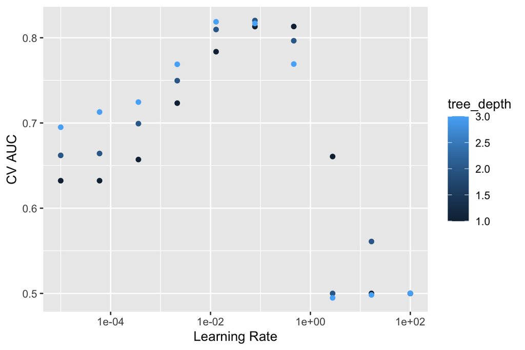

```r
gb_fit %>%
  collect_metrics() %>%
  print(width = Inf) %>%
  filter(.metric == "roc_auc") %>%
  ggplot(mapping = aes(x = learn_rate, y = mean, color = tree_depth)) +
  geom_point() +
  labs(x = "Learning Rate", y = "CV AUC") +
  scale_x_log10()
```

```r
list(logit_fit, rf_fit, gb_fit) %>%
  map(
    ~ .x %>%
      show_best("roc_auc")
    )
```

```
[[1]]
# A tibble: 5 × 8
  penalty mixture .metric .estimator  mean     n std_err .config
    <dbl>   <dbl> <chr>   <chr>      <dbl> <int>   <dbl> <chr>
1 0.00231    0.75 roc_auc binary     0.755     5 0.00231 Preprocessor1_Model338
2 0.00351    0.5  roc_auc binary     0.755     5 0.00234 Preprocessor1_Model240
3 0.00152    1    roc_auc binary     0.755     5 0.00232 Preprocessor1_Model436
4 0.00187    0.75 roc_auc binary     0.755     5 0.00234 Preprocessor1_Model337
5 0.00187    1    roc_auc binary     0.755     5 0.00230 Preprocessor1_Model437

[[2]]
# A tibble: 5 × 8
   mtry trees .metric .estimator  mean     n std_err .config
  <int> <int> <chr>   <chr>      <dbl> <int>   <dbl> <chr>
1     2   300 roc_auc binary     0.810     5 0.00372 Preprocessor1_Model06
2     1   200 roc_auc binary     0.810     5 0.00235 Preprocessor1_Model02
3     1   300 roc_auc binary     0.809     5 0.00278 Preprocessor1_Model03
4     2   200 roc_auc binary     0.809     5 0.00319 Preprocessor1_Model05
5     3   300 roc_auc binary     0.806     5 0.00420 Preprocessor1_Model09

[[3]]
# A tibble: 5 × 8
  tree_depth learn_rate .metric .estimator  mean     n std_err .config
       <int>      <dbl> <chr>   <chr>      <dbl> <int>   <dbl> <chr>
1          2     0.0774 roc_auc binary     0.820     5 0.00248 Preprocessor1_Mo…
2          3     0.0129 roc_auc binary     0.819     5 0.00239 Preprocessor1_Mo…
3          3     0.0774 roc_auc binary     0.817     5 0.00297 Preprocessor1_Mo…
4          1     0.464  roc_auc binary     0.813     5 0.00287 Preprocessor1_Mo…
5          1     0.0774 roc_auc binary     0.813     5 0.00225 Preprocessor1_Mo…
```

```r
list(logit_fit, rf_fit, gb_fit) %>%
  map(
    ~ .x %>%
      select_best("roc_auc")
    ) %>%
  set_names("best_logit", "best_rf", "best_gb") %>%
  list2env(.GlobalEnv) %>%
  invisible()

best_logit
```

```
# A tibble: 1 × 3
  penalty mixture .config
    <dbl>   <dbl> <chr>
1 0.00231    0.75 Preprocessor1_Model338
```

```r
best_rf
```

```
# A tibble: 1 × 3
   mtry trees .config
  <int> <int> <chr>
1     2   300 Preprocessor1_Model06
```

```r
best_gb
```

```
# A tibble: 1 × 3
  tree_depth learn_rate .config
       <int>      <dbl> <chr>
1          2     0.0774 Preprocessor1_Model17
```

3. Compare model classification performance on the test set. Report both the area under ROC curve and accuracy for each model.

```r
# Final workflows
list(
  list(logit_wf, rf_wf, gb_wf),
  list(best_logit, best_rf, best_gb)
  ) %>%
  pmap(
    ~ .x %>%
      finalize_workflow(.y)
  ) %>%
  set_names("final_wf_logit", "final_wf_rf", "final_wf_gb") %>%
  list2env(.GlobalEnv) %>%
  invisible()

final_wf_logit
```

```
══ Workflow ════════════════════════════════════════════════════════════════════
Preprocessor: Recipe
Model: logistic_reg()

── Preprocessor ────────────────────────────────────────────────────────────────
5 Recipe Steps

• step_impute_mean()
• step_impute_mode()
• step_zv()
• step_dummy()
• step_normalize()

── Model ───────────────────────────────────────────────────────────────────────
Logistic Regression Model Specification (classification)

Main Arguments:
  penalty = 0.00231012970008316
  mixture = 0.75

Engine-Specific Arguments:
  standardize = FALSE

Computational engine: glmnet
```

```r
final_wf_rf
```

```
══ Workflow ════════════════════════════════════════════════════════════════════
Preprocessor: Recipe
Model: rand_forest()

── Preprocessor ────────────────────────────────────────────────────────────────
3 Recipe Steps

• step_impute_mean()
• step_impute_mode()
• step_zv()

── Model ───────────────────────────────────────────────────────────────────────
Random Forest Model Specification (classification)

Main Arguments:
  mtry = 2
  trees = 300

Computational engine: ranger
```

```r
final_wf_gb
```

```
══ Workflow ════════════════════════════════════════════════════════════════════
Preprocessor: Recipe
Model: boost_tree()

── Preprocessor ────────────────────────────────────────────────────────────────
4 Recipe Steps

• step_impute_mean()
• step_impute_mode()
• step_zv()
• step_dummy()

── Model ───────────────────────────────────────────────────────────────────────
Boosted Tree Model Specification (classification)

Main Arguments:
  trees = 1000
  tree_depth = 2
  learn_rate = 0.0774263682681127

Computational engine: xgboost
```

```r
#Fit the whole training set, then predict the test cases
list(final_wf_logit, final_wf_rf, final_wf_gb) %>%
  map(
    ~ .x %>%
      last_fit(data_split)
    ) %>%
  set_names("final_fit_logit", "final_fit_rf", "final_fit_gb") %>%
  list2env(.GlobalEnv) %>%
  invisible()

final_fit_logit
```

```
# Resampling results
# Manual resampling
# A tibble: 1 × 6
  splits                id               .metrics .notes   .predict…¹ .workflow
  <list>                <chr>            <list>   <list>   <list>     <list>
1 <split [26575/26575]> train/test split <tibble> <tibble> <tibble>   <workflow>
# … with abbreviated variable name ¹.predictions
```

```r
final_fit_rf
```

```
# Resampling results
# Manual resampling
# A tibble: 1 × 6
  splits                id               .metrics .notes   .predict…¹ .workflow
  <list>                <chr>            <list>   <list>   <list>     <list>
1 <split [26575/26575]> train/test split <tibble> <tibble> <tibble>   <workflow>
# … with abbreviated variable name ¹.predictions
```

```r
final_fit_gb
```

```
# Resampling results
# Manual resampling
# A tibble: 1 × 6
  splits                id               .metrics .notes   .predict…¹ .workflow
  <list>                <chr>            <list>   <list>   <list>     <list>
1 <split [26575/26575]> train/test split <tibble> <tibble> <tibble>   <workflow>
# … with abbreviated variable name ¹.predictions
```

```r
# Test metrics
list(final_fit_logit, final_fit_rf, final_fit_gb) %>%
  map(collect_metrics)
```

```
[[1]]
# A tibble: 2 × 4
  .metric  .estimator .estimate .config
  <chr>    <chr>          <dbl> <chr>
1 accuracy binary         0.901 Preprocessor1_Model1
2 roc_auc  binary         0.746 Preprocessor1_Model1

[[2]]
# A tibble: 2 × 4
  .metric  .estimator .estimate .config
  <chr>    <chr>          <dbl> <chr>
1 accuracy binary         0.904 Preprocessor1_Model1
2 roc_auc  binary         0.813 Preprocessor1_Model1

[[3]]
# A tibble: 2 × 4
  .metric  .estimator .estimate .config
  <chr>    <chr>          <dbl> <chr>
1 accuracy binary         0.906 Preprocessor1_Model1
2 roc_auc  binary         0.813 Preprocessor1_Model1
```